# maldiscrim-demo

### 5. Visualizing Discriminant Latent Spaces

The package includes advanced graphic functions to inspect microbial strain segregation within the projection subspaces.2D Score Projections with Class Probabilities (plotSpectra2D)This function displays the score map along the first two PLS dimensions. Enabling show_proba = TRUE applies strict discrete opacity tiers ($1.0, 0.6,$ or $0.2$) based on the maximum posterior LDA probability, helping users visually isolate taxonomic uncertainty zones.

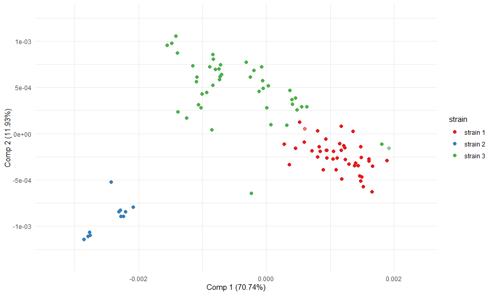

```r
plotSpectra2D(fit_model, comp = c(1, 2), show_proba = TRUE , palette = NULL)
```

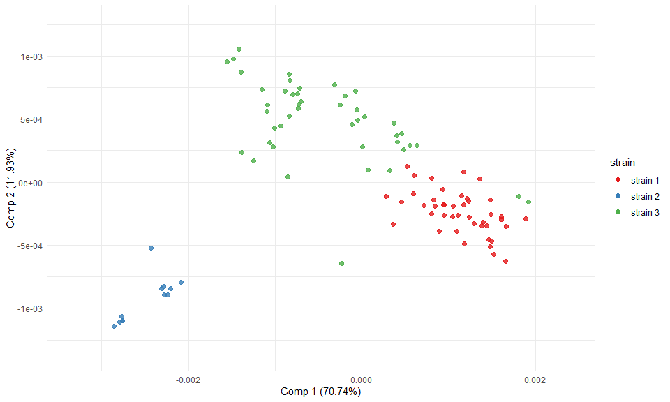

```r
plotSpectra2D(fit_model, comp = c(1, 2), show_proba = FALSE, palette = NULL)
```

**Interactive 3D Scores Cloud (plotSpectra3D)** To analyze complex cluster sub-structures, plotSpectra3D builds an interactive 3D scatter plot using plotly. Axes automatically integrate individual explained variance percentages, and plotting ranges expand by 10% to prevent marker edge truncation.

```r
# Generates an interactive 3D plot (supporting zoom and rotation)
plotSpectra3D(fit_model, comp = c(1, 2, 3), show_proba = FALSE, palette = NULL)
```

[interactive chart not shown]

**UMAP Non-linear Embedding Projection (plotSpectraUMAP)** When high biological proximity between distinct strains creates non-linear trajectories within the PLS score space, plotSpectraUMAP projects the complete PLS score matrix onto a 2D UMAP layout.

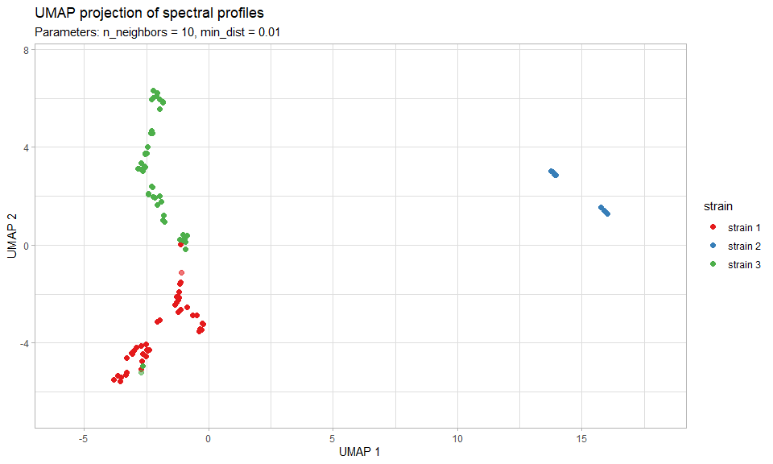

```r
plotSpectraUMAP(fit_model, n_neighbors = 10, min_dist = 0.01, show_proba = TRUE)
```

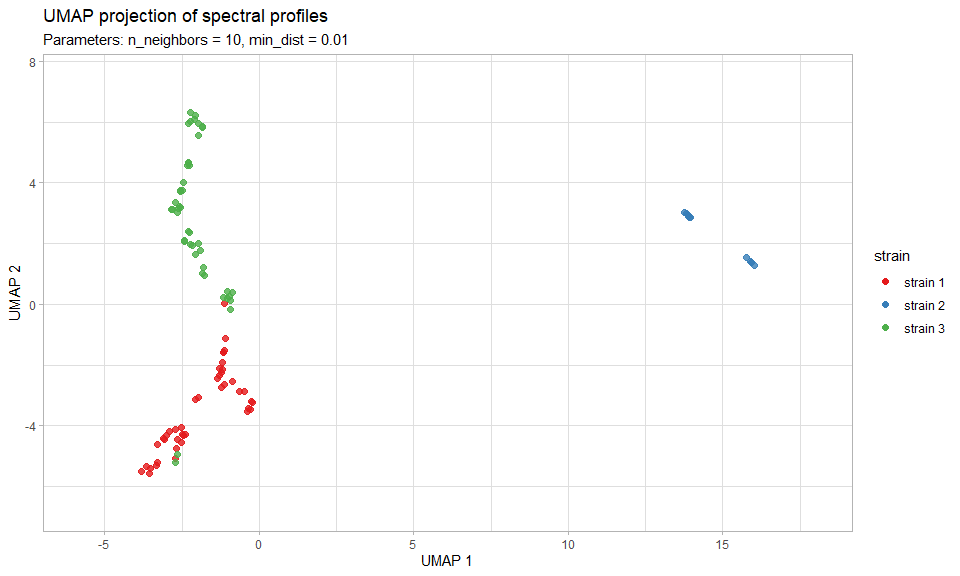

```r
plotSpectraUMAP(fit_model, n_neighbors = 10, min_dist = 0.01, show_proba = FALSE)
```

**Model Diagnostics: Variance and Biomarker Trackers (plotPLSvar & plotPLSweights)** To assist in model interpretation, plotPLSvar tracks individual variance decay across components, while plotPLSweights plots loading profiles across mass channels to expose the specific $m/z$ biomarkers driving the strain discrimination.

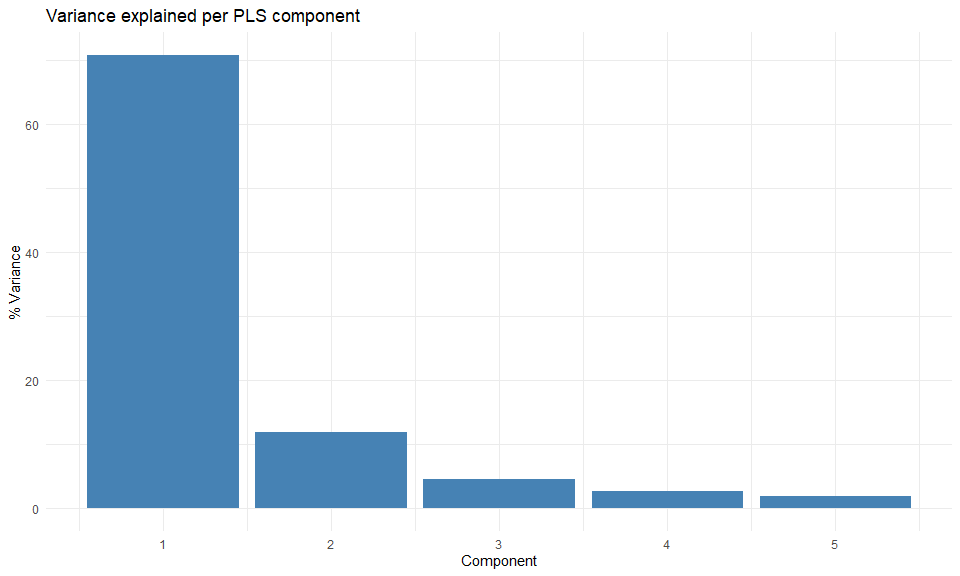

```r
# Variance scree plot
plotPLSvar(fit_model)
```

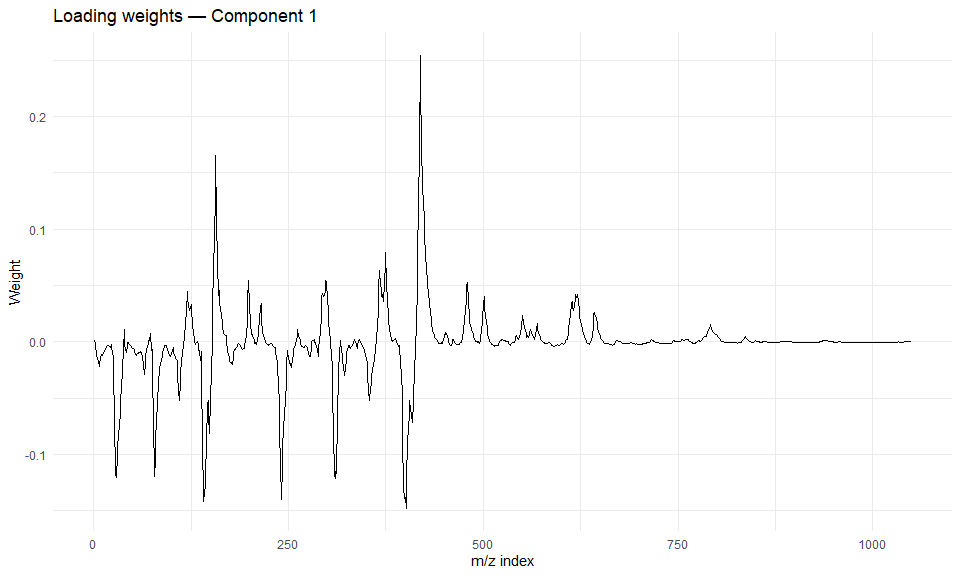

```r
# Identify influential m/z regions on Component 1
plotPLSweights(fit_model, comp = 1)
```

### 6. Model Summary

Once the model is fitted, `summary()` provides a structured diagnostic overview of the entire FPLS-DA pipeline in a single call. It covers four sections: the functional decomposition settings, the PLS dimension reduction statistics, the training data composition, and the in-sample classification performance.

```r
s <- summary(fit_model)
```

```
#> =======================================================
#>  FPLS-DA Model Summary
#> =======================================================
#>
#> [ 1 ] Functional Decomposition
#> -------------------------------------------------------
#>   Method           : bsplines
#>   Number of bases  : 1050
#>   Argument range   : [2001, 22664]
#>
#> [ 2 ] PLS Dimension Reduction
#> -------------------------------------------------------
#>   Components searched  : 20
#>   Components retained  : 5
#>   Components removed   : 0  (near-zero variance)
#>   Cumulative variance  : 91.9%
#>
#> [ 3 ] Training Data
#> -------------------------------------------------------
#>   Samples : 100
#>   Groups  : 3
#>
#>   Distribution per group:
#> true_labels
#> strain 1 strain 2 strain 3
#>       43       12       45
#>
#> [ 4 ] In-Sample Classification Performance
#> -------------------------------------------------------
#>   Overall accuracy : 96.0%
#>
#>   Confusion matrix :
#>           Actual
#> Predicted  strain 1 strain 2 strain 3
#>   strain 1       41        0        2
#>   strain 2        0       12        0
#>   strain 3        2        0       43
#>
#>   Per-group recall:
#>     Group Recall
#>  strain 1  95.3%
#>  strain 2 100.0%
#>  strain 3  95.6%
#>
#> =======================================================
```

The function can also print a formatted report directly to the console. The returned object `s` also allows programmatic access to every computed statistic without re-running the summary.

```r
# Overall accuracy
cat(sprintf("Overall in-sample accuracy : %.1f%%\n", s$accuracy * 100))
```

```
#> Overall in-sample accuracy : 96.0%
```

```r
# Per-group recall
print(s$recall)
```

```
#>  strain 1  strain 2  strain 3
#> 0.9534884 1.0000000 0.9555556
```

```r
# Full confusion matrix
print(s$confusion)
```

```
#>           Actual
#> Predicted  strain 1 strain 2 strain 3
#>   strain 1       41        0        2
#>   strain 2        0       12        0
#>   strain 3        2        0       43
```

### 7. Deep Learning Classification with Functional Neural Networks (`FNN`)

For complex discrimination tasks, `maldiscrim` provides a Functional Neural Network (FNN) pipeline implemented in Python via `reticulate` and TensorFlow. The FNN captures non-linear spectral relationships that linear methods such as FPLS-DA may miss.

#### 7.1 Training the FNN

Training a FNN model is computationally intensive. For demonstration purposes, this vignette loads a pre-trained model object directly from the package cache.

```r
data("fnn_model")
```

`fitFNN` trains the Functional Neural Network on a preprocessed spectral matrix. The function handles Python environment setup, data formatting, model compilation, and early stopping automatically.

```r
# Full training example (take more time)
fnn_model_trained <- fitFNN(
  data = spectra100,
  trainSize = 0.8,
  batchSize = 32L,
  nbEpochs = 50L,
  stepsPerEpoch = 16L,
  patience = 5L,
  monitor = "val_loss",
  firstLayer = list(nFilters = 50L, nFunctions = 100L, resolution = 500L, basisType =
    "Fourier", activation = "elu"),
  secondLayer = list(nFilters = 5L, nFunctions = 70L, resolution = 200L, basisType =
    "Fourier", activation = "elu"),
  finalLayer = list(nFunctions = 50L, resolution = 19966L, basisType = "Fourier",
    activation = "softmax", pooling = TRUE),
  outputPath = "outputs/fnn",
  verbose = TRUE
)
```

#### 7.2 Network Architecture

Before training, `architectureFNN` allows the user to inspect and configure the network layout — number of filters, kernel sizes, pooling sizes, and dense units across the three main blocks (two functional convolutional blocks and a final classification head). Calling it without arguments displays the default configuration.

```r
# Display and inspect the default FNN architecture
architectureFNN(fnn_model)
```

[output not shown]

#### 7.3 Model Summary

`summary()` prints a structured report of the FNN configuration and in-sample classification performance, following the same interface as `summary.FPLS_DA`.

```r
s_fnn <- summary(fnn_model)
```

```
#> ========================================================
#>  FNN Model Summary
#> ========================================================
#>
#> [ 1 ] Architecture
#> --------------------------------------------------------
#>   Layer 1 (conv)  : 50 filters, Fourier (100 fn, res 500), activation : elu
#>   Layer 2 (conv)  : 5 filters, Fourier (70 fn, res 200), activation : elu
#>   Layer 3 (dense) : 3 classes, Fourier (50 fn, res 19966), activation : softmax
#>   Trainable parameters : 23,250
#>
#>
#> [ 2 ] Training
#> --------------------------------------------------------
#>   Epochs run / set    : 22 / 50   (best epoch: 17)
#>   Early stopping      : monitor = val_loss, patience = 5
#>   Batch size / split  : 32  |  80% train / 20% validation
#>
#>                 Train       Validation
#>   Loss          0.0686      0.2761
#>   Accuracy      97.5%       95.0%
#>
#>
#> [ 3 ] Performance  (n = 100, 3 groups)
#> --------------------------------------------------------
#>   Overall accuracy : 97.0%
#>
#>   Confusion matrix :
#>           Reference
#> Prediction strain 1 strain 2 strain 3
#>   strain 1       42        0        2
#>   strain 2        0       12        0
#>   strain 3        1        0       43
#>
#>   Per-group recall:
#>     Group Recall
#>  strain 1  97.7%
#>  strain 2 100.0%
#>  strain 3  95.6%
```

```r
# Overall accuracy
cat(sprintf("FNN overall in-sample accuracy : %.1f%%\n", s_fnn$accuracy * 100))
```

```
#> FNN overall in-sample accuracy : 97.0%
```

```r
# Per-group recall
print(s_fnn$recall)
```

```
#>  strain 1  strain 2  strain 3
#> 0.9767442 1.0000000 0.9555556
```

```r
# Full confusion matrix
print(s_fnn$confusion)
```

```
#>           Reference
#> Prediction strain 1 strain 2 strain 3
#>   strain 1       42        0        2
#>   strain 2        0       12        0
#>   strain 3        1        0       43
```

#### 7.4 Prediction

`predict.FNN` projects new spectral data through the trained network and returns the predicted class and the associated maximum posterior probability for each sample. The optional `threshold` argument flags low-confidence predictions as `"Doubty"`.

```r
# Predict on training data (fitted values)
pred_fnn <- predict(fnn_model)
# First predicted classes
head(pred_fnn$class)
```

```
#> [1] "strain 1" "strain 1" "strain 1" "strain 1" "strain 1" "strain 1"
```

#### 7.5 Diagnostic Plots

**Training History (`plotTrainingFNN`)**

Monitors convergence and helps identify potential overfitting by displaying loss and accuracy curves for both the training and validation sets across epochs.

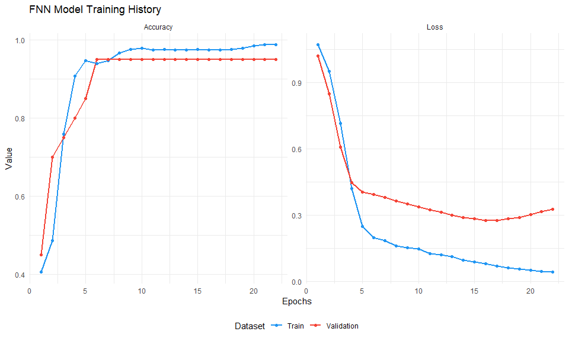

```r
plotTrainingFNN(fnn_model)
```

**In-Sample Confusion Matrix (`plotConfusionFNN`)**

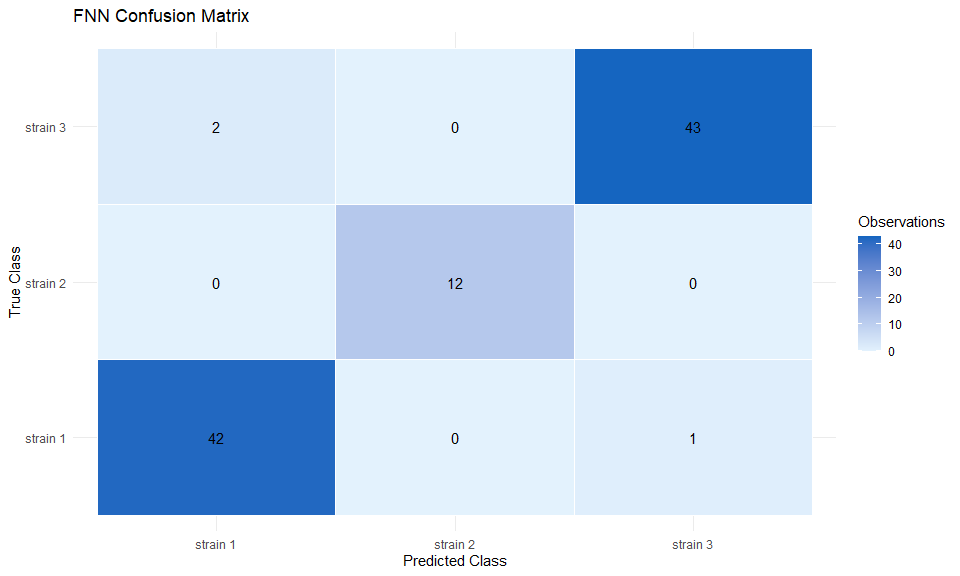

```r
plotConfusionFNN(fnn_model)
```

**Latent Space Projections (`plotUMAPFNN`, `plotMDSFNN`)**

Evaluate cluster separation across different activation levels (logits vs. softmax). Statistical confidence ellipses enclose distinct biological strains.

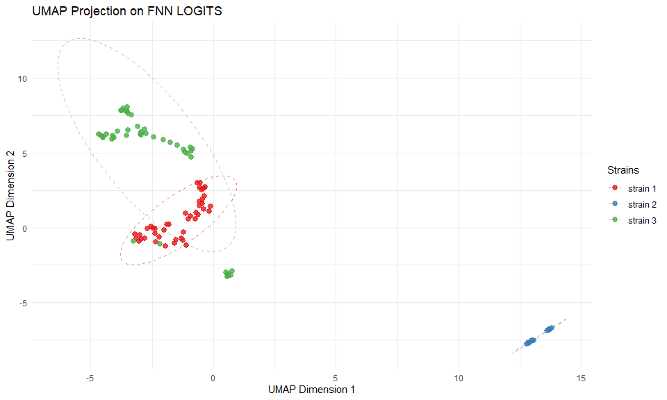

```r
plotUMAPFNN(fnn_model, on = "logits",  seed = 42)
```

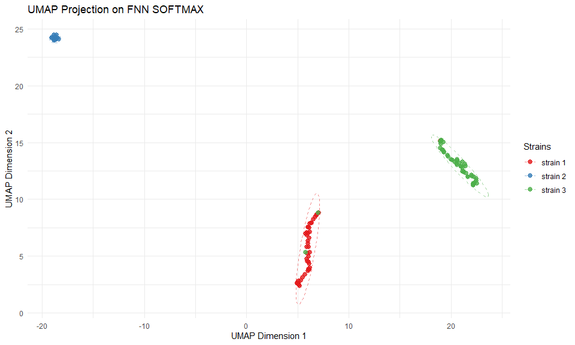

```r
plotUMAPFNN(fnn_model, on = "softmax", seed = 42)
```

#### 7.6 Interpretability

**Interpretability: Grad-CAM Attribution (`plotGradCamFNN`)**

Highlights the spectral regions that most influenced the network’s decision for a given sample and target class, using gradient-weighted class activation maps from the last functional convolutional layer.

```r
# plotGradCamFNN(fnn_model, classIndex = 1, sampleIndex = 1)
```

**Interpretability: Occlusion Sensitivity (`plotOcclusionFNN`)**

Systematically masks spectral windows and monitors the resulting drop in class probability, mapping a sensitivity profile across the full m/z domain.

```r
# plotOcclusionFNN(fnn_model, classIndex = 1, sampleIndex = 1, windowSize = 20)
```

**Interpretability: Filter Activations (`plotActivationFNN`)**

Visualizes the feature map outputs of each filter in the first functional convolutional layer for a chosen sample.

```r
# plotActivationFNN(fnn_model, sampleIndex = 1)
```

**Interpretability: Activation Maximization (`plotActivationMaxFNN`)**

Uses gradient ascent to synthesize an idealized pseudo-spectrum that maximizes the prediction score for a specific target class, revealing what the network “expects” a given strain to look like.

```r
# plotActivationMaxFNN(fnn_model, classIndex = 1, steps = 50)
```

### 8. Auto-Supervised Classification via Transfer Learning (`transferFNN`)

#### 8.1 Concept

Transfer learning is a machine learning paradigm in which a model pre-trained on a source task is reused as the starting point for a related target task. Rather than initializing all network weights randomly, the transferred backbone carries representations already learned from a reference dataset, allowing the model to converge faster and more reliably — particularly when the target dataset is small, which is a common scenario in microbiological settings where acquiring sufficient biological replicates per strain is resource-intensive.

In `maldiscrim`, `transferFNN` leverages the reference Functional Neural Network bundled with the package, trained on *S. thermophilus* reference spectra. The backbone — the two `FunctionalConvolution` layers that capture generic spectral representations — is reused and selectively frozen, while a new `FunctionalDense` classification head is grafted and trained from scratch on the new target data. Crucially, the source training data is never redistributed: only the learned weights are carried over.

#### 8.2 Transfer Strategies

Three freezing strategies control how much of the source backbone is retrained on the target data:

| Strategy | Frozen layers | Trainable layers |
| --- | --- | --- |
| `"feature_extraction"` (default) | Both `FunctionalConvolution` | New head only |
| `"fine_tune_partial"` | First `FunctionalConvolution` | Second conv. + new head |
| `"fine_tune_full"` | None | Entire network + new head |

The `nFreezeLayers` argument allows overriding the strategy with a direct integer if finer control is needed.

#### 8.3 Training

`transferFNN` accepts the same data format as `fitFNN` — a preprocessed spectral matrix with strain labels as row names. When `sourceModel = NULL` (default), the package’s bundled pre-trained model is used automatically.

For demonstration, we first simulate a new set of spectra representing hypothetical new strains, using `SimulateSpectrum` as introduced in Section 4. The transfer learning call is shown below; as with `fitFNN`, training is computationally intensive and is therefore presented with `eval = FALSE`.

```r
# Simulate new target spectra
new_spectra <- SimulateSpectrum(data = spectra100, n = 60, k = 3, clust_method = "gmm")
```

```r
# Transfer learning from the package's bundled pre-trained FNN
# sourceModel = NULL (default) loads the reference model automatically
transfer_model <- transferFNN(
  data = new_spectra, sourceModel = NULL, strategy = "feature_extraction", nbEpochs  = 50L,
  stepsPerEpoch = 16L,patience = 5L, monitor = "val_loss",
  finalLayer    = list(nFunctions = 50L, resolution = 19966L, basisType  = "Fourier", activation = "softmax",
                       pooling    = TRUE), outputPath = "outputs/transferFNN", verbose    = TRUE)
```

A custom source model produced by a previous `fitFNN` or `transferFNN` call can also be supplied explicitly via the `sourceModel` argument — for instance, when targeting a species that differs substantially from the bundled reference:

```r
# Advanced usage: supply a custom source model
transfer_model <- transferFNN(sourceModel = fnn_model, data  = new_spectra, strategy    = "fine_tune_partial")
```

#### 8.4 Post-Training Analysis

The object returned by `transferFNN` is of class `"FNN"`, identical in structure to the output of `fitFNN`. All downstream functions — `summary()`, `predict()`, and the full suite of diagnostic plots — therefore apply without modification, following the exact same interface described in Section 7.

```r
# Structured diagnostic overview
summary(transfer_model)
```

```r
# Predict on new spectral data
pred_transfer <- predict(transfer_model, newdata = new_spectra)

# Predicted classes and associated maximum posterior probabilities
head(pred_transfer$class)
head(pred_transfer$probability)
```

```r
# Training convergence
plotTrainingFNN(transfer_model)

# In-sample confusion matrix
plotConfusionFNN(transfer_model)

# Latent space projections
plotUMAPFNN(transfer_model, on = "softmax", seed = 42)
```